# RandomForest

Manpreet S. Katari

4/23/2018

## Random Forest

### Resources

The following sources were helpful in creating the notes shown here.

[Random Forest - Berkeley](https://www.stat.berkeley.edu/~breiman/RandomForests/cc_home.htm)

[randomForest - cran package](https://www.r-bloggers.com/random-forests-in-r/)

### Random Forest

The main concept behind Random Forests is to generate many decision trees by sampling both, the observations and the variables. Observation are randomized by selecting same number of observations but allowing for observations to be selected again ( with replacement ). Variables are randomized by selecting a small number ( often referred to as **m**) compared to the total number of observations. Each tree in this forest is grown without any pruning. Pruning is the process of trimming the tree to avoid over-fitting. In this case we donât prune at all.

Now, when an input is provided, all the trees will vote on a given result and the outcome with the most votes will win. One often has to adjust the **m** to identify the optimal results.

Random Forest is a popular method for predictive analysis because it is fast and less likely to overfit. The observations are randomly selected ( with replacement ) the remaining dataset is referred to as âout of bagâ (OOB) data. This is the same idea as the Leave Out set. Random Forest will try to classify the OOB data and determine accuracy of the model. For this reason one does not have to perform any cross validation, because every time a tree is created, it goes through a round of assesment.

### Variable importance

To calculate whether a variable is imporant you simply perform the following steps:

- Count the number of correct predictions
- For a given variable, simply randomize/shuffle the values and then count the number of correct prediction.
- Repeat this in all tree for that one variable. The average difference of the predictions minus the correct predictions is the importance score of the variable.

**Gini** impurity is very similar to Entropy ( or the gain of information ) except the calculations are slightly different.

### Dataset

Letâs use our 15K patient data to see how Random Forest performs in our dataset.

There are two popular packages to perform the analysis. One is the **party** package that we used earlier for Decision Trees, and there is also the **randomForest** package

```r
data = read.table("all.15k.patients.txt", header=T)
head(data)
```

```
##   patientid dateofbirth maritalstatus race ageatdiagnosis alivestatus
## 1  pid00001  28/01/1932             5    2             61           0
## 2  pid00002  07/05/1934             2    3             60           0
## 3  pid00003  14/04/1921             5    3             76           0
## 4  pid00004  08/11/1931             3    3             61           1
## 5  pid00005  08/01/1922             2    3             74           1
## 6  pid00006  03/12/1939             2    3             55           0
##   survivaltime grade nodesexam nodespos extent nodalstatus size pgr er
## 1          110     3        32        3     10           6   60   2  2
## 2          100     2        13        1     10           6   15   1  1
## 3           70     3         8        0     10           0    8   1  1
## 4           31     3        20        0     10           0   10   2  2
## 5           47     2        16        8     10           6   15   2  1
## 6          100     3        19        0     10           0   48   1  1
```

Letâs also limit the variables we want to use.

```r
specific_data = data[,c("alivestatus","grade","nodespos","nodesexam","size","pgr","er")]
```

Writing the randomForest model is the same as writing any other model, but first letâs make sure alivestatus is a factor. Also we will use the **importance=T** option to calculate how important each variable is.

```r
specific_data$alivestatus = as.factor(specific_data$alivestatus)
library(randomForest)
datarf = randomForest(alivestatus ~ ., data=specific_data, importance=T)
datarf
```

```
##
## Call:
##  randomForest(formula = alivestatus ~ ., data = specific_data,      importance = T)
##                Type of random forest: classification
##                      Number of trees: 500
## No. of variables tried at each split: 2
##
##         OOB estimate of  error rate: 16.57%
## Confusion matrix:
##       0   1 class.error
## 0 11782 463  0.03781135
## 1  2023 732  0.73430127
```

There are some standard plots that are available in the results

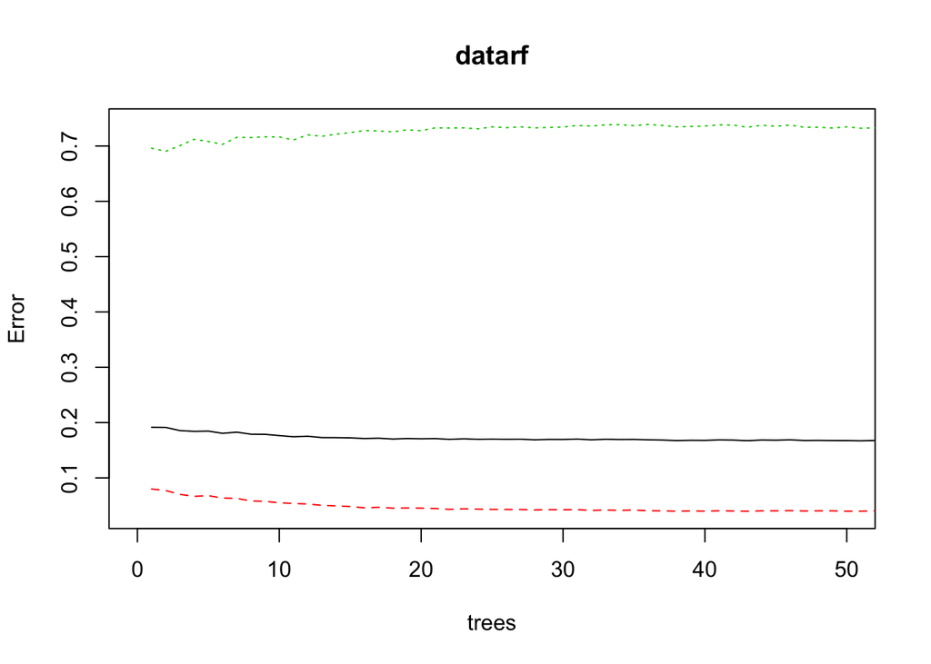

```r
plot(datarf, xlim=c(0,50))
```

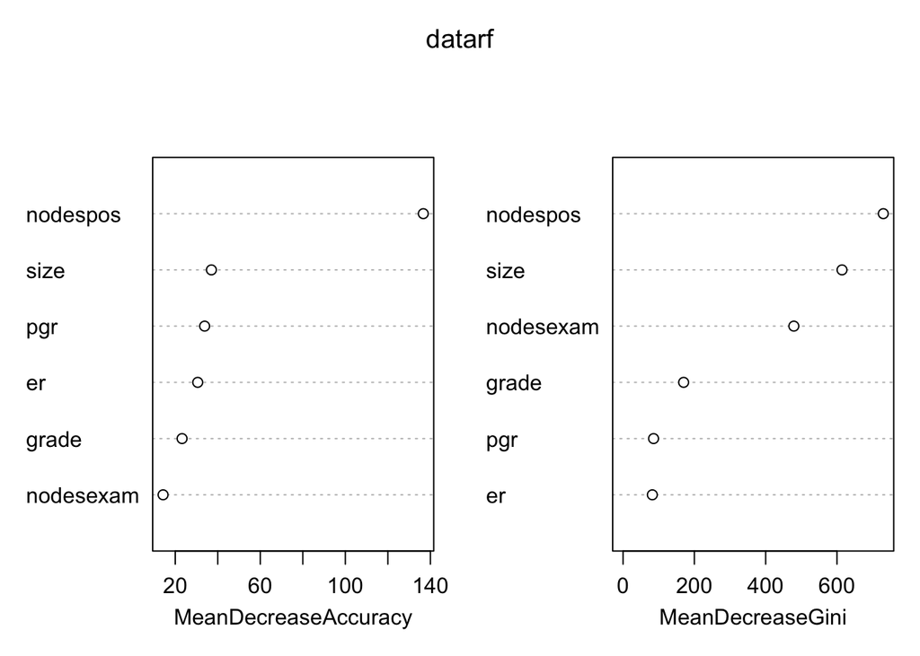

```r
varImpPlot(datarf)
```

The first plot shows how much accuracy is affected by changing the values in the different variable. Nodespos is the most important because changing its values alters the results the most.

The second plot shows a measurement that is similar to Information gain. Again nodespos has the most informative variable if the patient will live or die.

### Exercise:

Try use the value **m** using the **mtry** option in **randomForest**. Do the results get better or worse?

## cForest() function

Letâs repeat the analysis using the **cForest()** function in the **party** package. cForest is much slower in creating and specially predicting using very deep trees so letâs just do 100 trees.

```r
library("party")
dataparty.rf = cforest(alivestatus ~ grade + nodespos + nodesexam + size + pgr + er,
                       data=specific_data,
                       controls=cforest_unbiased(ntree=100,mtry=2))
dataparty.rf
```

```
##
##   Random Forest using Conditional Inference Trees
##
## Number of trees:  100
##
## Response:  alivestatus
## Inputs:  grade, nodespos, nodesexam, size, pgr, er
## Number of observations:  15000
```

Letâs look at the results. Did this perform better than **randomForest**?

```r
dataparty.rf.results = predict(dataparty.rf,OOB=TRUE)

table(dataparty.rf.results, specific_data$alivestatus)
```

```
##
## dataparty.rf.results     0     1
##                    0 11795  1990
##                    1   450   765
```

We can also get the probabilities for the predictions.

```r
dataparty.rf.results.prob = predict(dataparty.rf, OOB = T,type="prob")
dataparty.rf.results.prob[[1]]
```

```
##      alivestatus.0 alivestatus.1
## [1,]      0.484869      0.515131
```

What are the most important variables

```r
varimp(dataparty.rf)
```

```
##        grade     nodespos    nodesexam         size          pgr
## 0.0028297101 0.0410326087 0.0023967391 0.0038731884 0.0035960145
##           er
## 0.0008333333
```

### Drawing a tree

The following code was obtained from [stack exchange](https://stats.stackexchange.com/questions/205664/is-there-a-method-to-plot-the-output-of-a-random-forest-in-r).

[figure not shown]

```r
pt <- prettytree(dataparty.rf@ensemble[[1]],
                 names(dataparty.rf@data@get("input")))
nt <- new("BinaryTree")
nt@tree <- pt
nt@data <- dataparty.rf@data
nt@responses <- dataparty.rf@responses

plot(nt, type="simple")
```